# Sixth Week: Linear Models

House price prediction

Ali Gorji

2018-04-14 23:39:28

> با توجه به داده های قیمت منازل لطفا با سوالات زیر پاسخ دهید.

۱. ماتریس همبستگی متغیرهای مختلف را به دست آورده و سپس رسم نمایید. اعداد به دست آمده را با آزمون فرض معناداری همبستگی بسنجید و سپس ده متغیری که همبستگی بالاتری با قیمت دارند را مشخص نمایید.

```r
library(readr)
library(car)
```

```r
library(ggplot2)
library(highcharter)
library(dplyr)
house = read.csv("house/train.csv")
numericed_house = house %>% select_if(is.numeric)
cor(numericed_house, use = "complete.obs")
```

[output not shown]

[output cut: 335 more lines]

```
## TotRmsAbvGrd  -2.481218e-02  0.547067360
## Fireplaces    -3.140227e-02  0.461872689
## GarageYrBlt    9.596052e-03  0.504753018
## GarageCars    -3.350744e-02  0.647033611
## GarageArea    -1.620605e-02  0.619329622
## WoodDeckSF     1.480997e-02  0.336855121
## OpenPorchSF   -5.303516e-02  0.343353812
## EnclosedPorch -1.184577e-03 -0.154843204
## X3SsnPorch     2.073068e-02  0.030776594
## ScreenPorch   -4.118063e-03  0.110426815
## PoolArea      -5.388769e-02  0.092488120
## MiscVal        3.410608e-02 -0.036041237
## MoSold        -1.505766e-01  0.051568064
## YrSold         1.000000e+00 -0.011868823
## SalePrice     -1.186882e-02  1.000000000
```

```r
cor_result = c()
for(param in colnames(numericed_house)){
    cor_result = c(cor_result, cor.test(numericed_house$SalePrice, numericed_house[, param])$estimate)
}
price_cor = data.frame(parameter = colnames(numericed_house), correlation = cor_result)
price_cor %>% arrange(desc(correlation)) %>% top_n(11) -> top_correlation
```

۲. در یک تصویر نمودار پراکنش دو به دو ده متغیر بدست آمده به همراه قیمت را رسم نمایید و هم خطی بودن متغیرها را بررسی کنید

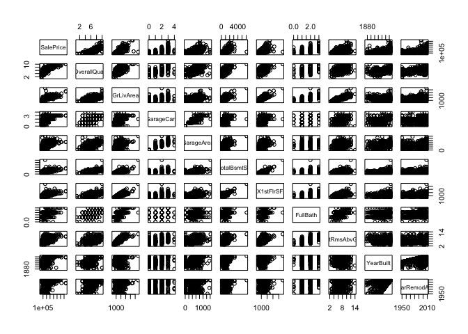

```r
reduced_house <- numericed_house[,as.character(top_correlation$parameter)]
plot(reduced_house)
```

۳. یک مدل خطی بر اساس ده متغیر برای پیش بینی قیمت برازش دهید. و سپس خلاصه نتایج مدل را به دست آورید.

```r
fit = lm(SalePrice ~ OverallQual + GrLivArea + GarageCars + GarageArea + TotalBsmtSF + X1stFlrSF + FullBath + TotRmsAbvGrd + YearBuilt + YearRemodAdd, data = reduced_house)
summary(fit)
```

```
##
## Call:
## lm(formula = SalePrice ~ OverallQual + GrLivArea + GarageCars +
##     GarageArea + TotalBsmtSF + X1stFlrSF + FullBath + TotRmsAbvGrd +
##     YearBuilt + YearRemodAdd, data = reduced_house)
##
## Residuals:
##     Min      1Q  Median      3Q     Max
## -489958  -19316   -1948   16020  290558
##
## Coefficients:
##                Estimate Std. Error t value Pr(>|t|)
## (Intercept)  -1.186e+06  1.291e+05  -9.187  < 2e-16 ***
## OverallQual   1.960e+04  1.190e+03  16.472  < 2e-16 ***
## GrLivArea     5.130e+01  4.233e+00  12.119  < 2e-16 ***
## GarageCars    1.042e+04  3.044e+03   3.422 0.000639 ***
## GarageArea    1.495e+01  1.031e+01   1.450 0.147384
## TotalBsmtSF   1.986e+01  4.295e+00   4.625 4.09e-06 ***
## X1stFlrSF     1.417e+01  4.930e+00   2.875 0.004097 **
## FullBath     -6.791e+03  2.682e+03  -2.532 0.011457 *
## TotRmsAbvGrd  3.310e+01  1.119e+03   0.030 0.976404
## YearBuilt     2.682e+02  5.035e+01   5.328 1.15e-07 ***
## YearRemodAdd  2.965e+02  6.363e+01   4.659 3.47e-06 ***
## ---
## Signif. codes:  0 '***' 0.001 '**' 0.01 '*' 0.05 '.' 0.1 ' ' 1
##
## Residual standard error: 37920 on 1449 degrees of freedom
## Multiple R-squared:  0.7737, Adjusted R-squared:  0.7721
## F-statistic: 495.4 on 10 and 1449 DF,  p-value: < 2.2e-16
```

۴. نمودار قیمت واقعی و قیمت پیش بینی را رسم نمایید و خوب بودن مدل را ارزیابی کنید.

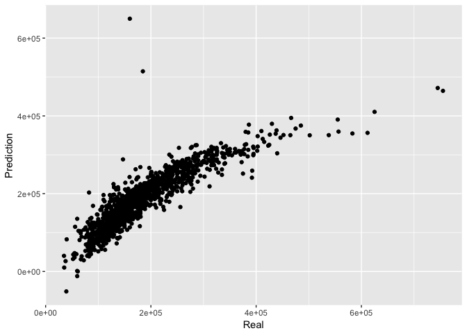

```r
yhat = predict(fit)
comparison_dataframe = data.frame(Real = reduced_house$SalePrice, Prediction = yhat)
ggplot(comparison_dataframe) + geom_point(aes(x = Real, y= Prediction))
```

***

۵. مقدار R-squared مدل را به دست آورید. آیا بر اساس این کمیت مدل به خوبی به داده ها برازش داده شده است؟ کمیت F-statistic را در خلاصه مدل تفسیر نمایید.

به طور کلی نمی توان بر اساس مقدار R-squared در مورد کیفیت فیت شدن داده ها نظر دقیقی داد. مقدار R-squared نشان دهنده این است که نسبت واریانس خطا به واریانس متغیر مستقل ما است و هر چه مقدار آن بیشتر باشد نشان می دهد واریانس در خطا ها کمتر از واریانس در متغیر مستقلمان است و احتمالا فیت بهتری انجام داده ایم. ولی در مجموع نمی توان بر اساس آن یک مدل را مدلی خوب یا بد نامید. در این جا نیز این مقدار در حدی بالا هست تا کمی از مدل ساخته شده اطمینان خاطر بیشتری پیدا کنیم!  
در حالی که R-squared یک تخمینی از میزان قوت رابطه بین مدل و مقدار واقعی متغیر مستقل ارائه می کند، تست F مشخص می کند آیا این رابطه از نظر آماری قابل توجه هست یا نه و بر اساس آن تستی ارائه می کند. در واقع F-statistic نشان می دهد داده ها تا چه میزان از میانگین فاصله دارند و مقدار بالای آن نشان دهنده پراکندگی بیشتر داده ها است. این تست مشخص با این فرض که در کنار هم قرار گرفتن این متغیر های مستقل تاثیری در بهبود وضعیت مدل ندارد به بررسی کنار هم قرار گرفتن آن ها می پردازد.  
در اینجا با توجه به پایین بودن مقدار p-value برای تست F، می توانیم به این نتیجه برسیم که در کنار هم قرار گرفتن این متغیر های مستقل می تواند مدل خوبی به ما بدهد. این نتیجه باعث می شود مقدار R-squared به دست آمده نیز قابل اعتماد تر شود و با خیال راحت آن را به عنوان معیاری از خوب بودن مدل در نظر بگیریم!

```r
summary(fit)$r.squared
```

```
## [1] 0.7736928
```

```r
summary(fit)
```

```
##
## Call:
## lm(formula = SalePrice ~ OverallQual + GrLivArea + GarageCars +
##     GarageArea + TotalBsmtSF + X1stFlrSF + FullBath + TotRmsAbvGrd +
##     YearBuilt + YearRemodAdd, data = reduced_house)
##
## Residuals:
##     Min      1Q  Median      3Q     Max
## -489958  -19316   -1948   16020  290558
##
## Coefficients:
##                Estimate Std. Error t value Pr(>|t|)
## (Intercept)  -1.186e+06  1.291e+05  -9.187  < 2e-16 ***
## OverallQual   1.960e+04  1.190e+03  16.472  < 2e-16 ***
## GrLivArea     5.130e+01  4.233e+00  12.119  < 2e-16 ***
## GarageCars    1.042e+04  3.044e+03   3.422 0.000639 ***
## GarageArea    1.495e+01  1.031e+01   1.450 0.147384
## TotalBsmtSF   1.986e+01  4.295e+00   4.625 4.09e-06 ***
## X1stFlrSF     1.417e+01  4.930e+00   2.875 0.004097 **
## FullBath     -6.791e+03  2.682e+03  -2.532 0.011457 *
## TotRmsAbvGrd  3.310e+01  1.119e+03   0.030 0.976404
## YearBuilt     2.682e+02  5.035e+01   5.328 1.15e-07 ***
## YearRemodAdd  2.965e+02  6.363e+01   4.659 3.47e-06 ***
## ---
## Signif. codes:  0 '***' 0.001 '**' 0.01 '*' 0.05 '.' 0.1 ' ' 1
##
## Residual standard error: 37920 on 1449 degrees of freedom
## Multiple R-squared:  0.7737, Adjusted R-squared:  0.7721
## F-statistic: 495.4 on 10 and 1449 DF,  p-value: < 2.2e-16
```

۶. بر اساس p-value سطح معناداری ضرایب تصمیم بگیرید که چه متغیرهایی در مدل سازی استفاده شود. بر اساس متغیرهای جدید دوباره مدل سازی کنید و نتایج رو گزارش دهید.

به نظر می آید حذف پارامترهایی با p-value بیش از ۰.۰۵ بتواند به بهبود مدل کمک کند. پس مدل جدیدی را بر این اساس تعریف می کنیم. با اینکار مقادیر p-value ها برای متغیر های مختلف کمتر شد ولی تغییر خاصی در مقدار R-squared رخ نداد.

```r
summary(fit)
```

```
##
## Call:
## lm(formula = SalePrice ~ OverallQual + GrLivArea + GarageCars +
##     GarageArea + TotalBsmtSF + X1stFlrSF + FullBath + TotRmsAbvGrd +
##     YearBuilt + YearRemodAdd, data = reduced_house)
##
## Residuals:
##     Min      1Q  Median      3Q     Max
## -489958  -19316   -1948   16020  290558
##
## Coefficients:
##                Estimate Std. Error t value Pr(>|t|)
## (Intercept)  -1.186e+06  1.291e+05  -9.187  < 2e-16 ***
## OverallQual   1.960e+04  1.190e+03  16.472  < 2e-16 ***
## GrLivArea     5.130e+01  4.233e+00  12.119  < 2e-16 ***
## GarageCars    1.042e+04  3.044e+03   3.422 0.000639 ***
## GarageArea    1.495e+01  1.031e+01   1.450 0.147384
## TotalBsmtSF   1.986e+01  4.295e+00   4.625 4.09e-06 ***
## X1stFlrSF     1.417e+01  4.930e+00   2.875 0.004097 **
## FullBath     -6.791e+03  2.682e+03  -2.532 0.011457 *
## TotRmsAbvGrd  3.310e+01  1.119e+03   0.030 0.976404
## YearBuilt     2.682e+02  5.035e+01   5.328 1.15e-07 ***
## YearRemodAdd  2.965e+02  6.363e+01   4.659 3.47e-06 ***
## ---
## Signif. codes:  0 '***' 0.001 '**' 0.01 '*' 0.05 '.' 0.1 ' ' 1
##
## Residual standard error: 37920 on 1449 degrees of freedom
## Multiple R-squared:  0.7737, Adjusted R-squared:  0.7721
## F-statistic: 495.4 on 10 and 1449 DF,  p-value: < 2.2e-16
```

```r
new_fit = lm(SalePrice ~ OverallQual + GrLivArea + GarageCars + TotalBsmtSF + X1stFlrSF + FullBath + YearBuilt + YearRemodAdd, data = reduced_house)
summary(new_fit)
```

```
##
## Call:
## lm(formula = SalePrice ~ OverallQual + GrLivArea + GarageCars +
##     TotalBsmtSF + X1stFlrSF + FullBath + YearBuilt + YearRemodAdd,
##     data = reduced_house)
##
## Residuals:
##     Min      1Q  Median      3Q     Max
## -482525  -19191   -1801   16208  289639
##
## Coefficients:
##                Estimate Std. Error t value Pr(>|t|)
## (Intercept)  -1.188e+06  1.284e+05  -9.255  < 2e-16 ***
## OverallQual   1.959e+04  1.188e+03  16.486  < 2e-16 ***
## GrLivArea     5.177e+01  3.097e+00  16.714  < 2e-16 ***
## GarageCars    1.395e+04  1.817e+03   7.680 2.92e-14 ***
## TotalBsmtSF   2.039e+01  4.269e+00   4.775 1.98e-06 ***
## X1stFlrSF     1.465e+01  4.919e+00   2.979  0.00294 **
## FullBath     -7.184e+03  2.644e+03  -2.717  0.00666 **
## YearBuilt     2.699e+02  5.017e+01   5.380 8.69e-08 ***
## YearRemodAdd  2.957e+02  6.362e+01   4.649 3.64e-06 ***
## ---
## Signif. codes:  0 '***' 0.001 '**' 0.01 '*' 0.05 '.' 0.1 ' ' 1
##
## Residual standard error: 37920 on 1451 degrees of freedom
## Multiple R-squared:  0.7734, Adjusted R-squared:  0.7721
## F-statistic: 618.9 on 8 and 1451 DF,  p-value: < 2.2e-16
```

۷. مدل خود را بر اساس باقی مانده نقص یابی کنید. سه محک normality, independance, Constant Variance را در نقص یابی خود در نظر بگیرید.

با توجه به نمودار به دست آمده از qqplot، می بینیم در انتهای خط داده ها از خط فاصله می گیرند و نمی توانیم داده ها را پیرو توزیع نرمال بدانیم! در ادامه نیز واریانس ها را برای متغیر های مختلف در نظر می گیریم تا هم خطی متغیر های مختلف را نسبت به هم در نظر بگیریم و می بینیم سه متغیر GrLivArea، GarageArea و GarageArea بسیار شبیه به هم هستند و استقلال ندارند. در ادامه نیز با توجه به نمودار می توانیم بگویم خطا ثابت نیست (واریانس ثابتی ندارد)

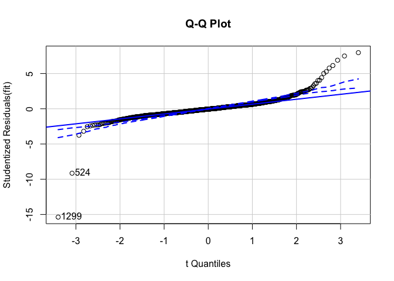

```
## [1]  524 1299
```

```r
qqPlot(fit, id.method="identify", simulate = TRUE, main="Q-Q Plot")
```

```r
vif(fit)
```

```
##  OverallQual    GrLivArea   GarageCars   GarageArea  TotalBsmtSF
##     2.748629     5.018752     5.250959     4.931012     3.602674
##    X1stFlrSF     FullBath TotRmsAbvGrd    YearBuilt YearRemodAdd
##     3.684726     2.215500     3.356517     2.345827     1.751047
```

```r
hchart(reduced_house$SalePrice - predict(new_fit, reduced_house))
```

[interactive chart not shown]

***

۸. داده ها را به پنج قسمت تقسیم کنید. بر اساس چهار قسمت مدل خطی را بسازید و صحت مدل را برای یک قسمت باقی مانده را تست کنید. خطای پیش بینی شما چقدر است؟

```r
reduced_house = reduced_house %>% arrange(SalePrice)
reduced_house = reduced_house[sample(nrow(reduced_house)),]
train <- reduced_house %>% slice(1:as.integer(0.8 * count(reduced_house)))
test <- reduced_house %>% slice(as.integer(0.8 * count(reduced_house)) : as.integer(count(reduced_house)))
train_fit = lm(SalePrice ~ OverallQual + GrLivArea + GarageCars + TotalBsmtSF + X1stFlrSF + FullBath + YearBuilt + YearRemodAdd, data = train)
summary(train_fit)
```

```
##
## Call:
## lm(formula = SalePrice ~ OverallQual + GrLivArea + GarageCars +
##     TotalBsmtSF + X1stFlrSF + FullBath + YearBuilt + YearRemodAdd,
##     data = train)
##
## Residuals:
##     Min      1Q  Median      3Q     Max
## -447115  -18939   -1994   15939  300083
##
## Coefficients:
##                Estimate Std. Error t value Pr(>|t|)
## (Intercept)  -1.205e+06  1.413e+05  -8.530  < 2e-16 ***
## OverallQual   1.931e+04  1.302e+03  14.830  < 2e-16 ***
## GrLivArea     5.039e+01  3.443e+00  14.636  < 2e-16 ***
## GarageCars    1.435e+04  1.996e+03   7.191 1.15e-12 ***
## TotalBsmtSF   1.269e+01  4.956e+00   2.561 0.010555 *
## X1stFlrSF     1.730e+01  5.714e+00   3.027 0.002524 **
## FullBath     -6.485e+03  2.961e+03  -2.190 0.028720 *
## YearBuilt     3.113e+02  5.544e+01   5.616 2.45e-08 ***
## YearRemodAdd  2.665e+02  7.015e+01   3.798 0.000153 ***
## ---
## Signif. codes:  0 '***' 0.001 '**' 0.01 '*' 0.05 '.' 0.1 ' ' 1
##
## Residual standard error: 37680 on 1159 degrees of freedom
## Multiple R-squared:  0.768,  Adjusted R-squared:  0.7664
## F-statistic: 479.5 on 8 and 1159 DF,  p-value: < 2.2e-16
```

```r
#We also omit FullBath
train_fit = lm(SalePrice ~ OverallQual + GrLivArea + GarageCars + TotalBsmtSF + X1stFlrSF + YearBuilt + YearRemodAdd, data = train)
summary(predict(train_fit, test)-test$SalePrice)
```

```
##    Min. 1st Qu.  Median    Mean 3rd Qu.    Max.
## -263764  -15883    1656   -1838   21399   94534
```

با توجه به بازه خطای به دست آمده به نظر می رسد مدل خوبی به دست آمده و خطای پیشبینی قابل قبول است.

۹. آیا قیمت ربط غیر خطی با یکی از ده متغیر استفاده شده دارد؟ بر اساس دستاوردهای خود مدل را بهتر نمایید.

برای مشخص کردن این منظور می توانیم از تست کوریلیشن استفاده کنیم ولی برای بهتر مشخص شدن مسئله از ویژوالیزیشن استفاده می کنیم. پس نمودار قیمت و پارامترهای مدل را کشیده و بررسی می کنیم:

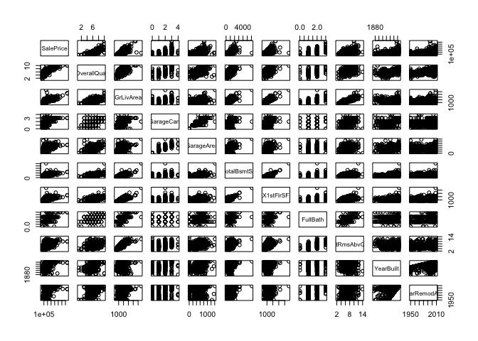

```r
train %>% plot()
```

با توجه به نمودار به دست آمده از کنار هم قرار گرفتن پارامتر های مختلف، به نظر می رسد متغیر OverallQual رابطه نمایی با قیمت داشته باشد و می توانیم این مسئله را در مدل لحاظ کنیم. خروجی به دست آمده نشان می دهد مقدار R-squared کمی بهبود یافته است.

```r
new_train_fit = lm(SalePrice ~ exp(OverallQual) + GrLivArea + GarageCars + TotalBsmtSF + X1stFlrSF + YearBuilt + YearRemodAdd, data = train)
summary(new_train_fit)
```

```
##
## Call:
## lm(formula = SalePrice ~ exp(OverallQual) + GrLivArea + GarageCars +
##     TotalBsmtSF + X1stFlrSF + YearBuilt + YearRemodAdd, data = train)
##
## Residuals:
##     Min      1Q  Median      3Q     Max
## -537986  -16855   -1732   14047  198966
##
## Coefficients:
##                    Estimate Std. Error t value Pr(>|t|)
## (Intercept)      -1.668e+06  1.210e+05 -13.784  < 2e-16 ***
## exp(OverallQual)  7.690e+00  4.824e-01  15.942  < 2e-16 ***
## GrLivArea         5.220e+01  2.779e+00  18.784  < 2e-16 ***
## GarageCars        1.766e+04  1.933e+03   9.132  < 2e-16 ***
## TotalBsmtSF       1.629e+01  4.827e+00   3.374 0.000764 ***
## X1stFlrSF         8.476e+00  5.616e+00   1.509 0.131537
## YearBuilt         4.392e+02  5.038e+01   8.717  < 2e-16 ***
## YearRemodAdd      4.211e+02  6.709e+01   6.276 4.88e-10 ***
## ---
## Signif. codes:  0 '***' 0.001 '**' 0.01 '*' 0.05 '.' 0.1 ' ' 1
##
## Residual standard error: 37260 on 1160 degrees of freedom
## Multiple R-squared:  0.7729, Adjusted R-squared:  0.7715
## F-statistic: 563.8 on 7 and 1160 DF,  p-value: < 2.2e-16
```

۱۰. بر اساس مدل نهایی به دست آمده نتایج پیش بینی خود را بر روی test.csv به دست آورید و در سایت kaggle در مسابقه House Prices: Advanced Regression Techniques بارگذاری نمایید. سپس لینک رتبه و عدد آن را ضمیمه تمرین کنید.

```r
test = read.csv("house/test.csv")
colnames(test)[44] = "X1stFlrSF"
kaggle_output = data.frame(test$Id)
kaggle_output$SalePrice = predict(new_train_fit, test)
colnames(kaggle_output) = c("Id", "SalePrice")
kaggle_output[is.na(kaggle_output)] = 178000
write_csv(kaggle_output, "output.csv")
```